# modélisation de l’évolution de la température dans le sol

artur Freeman

09/05/2022

# 1 importation des données

# 2 visualisation des données météo brutes

conversion des dates en jours de l’année et visualisation des données brutes

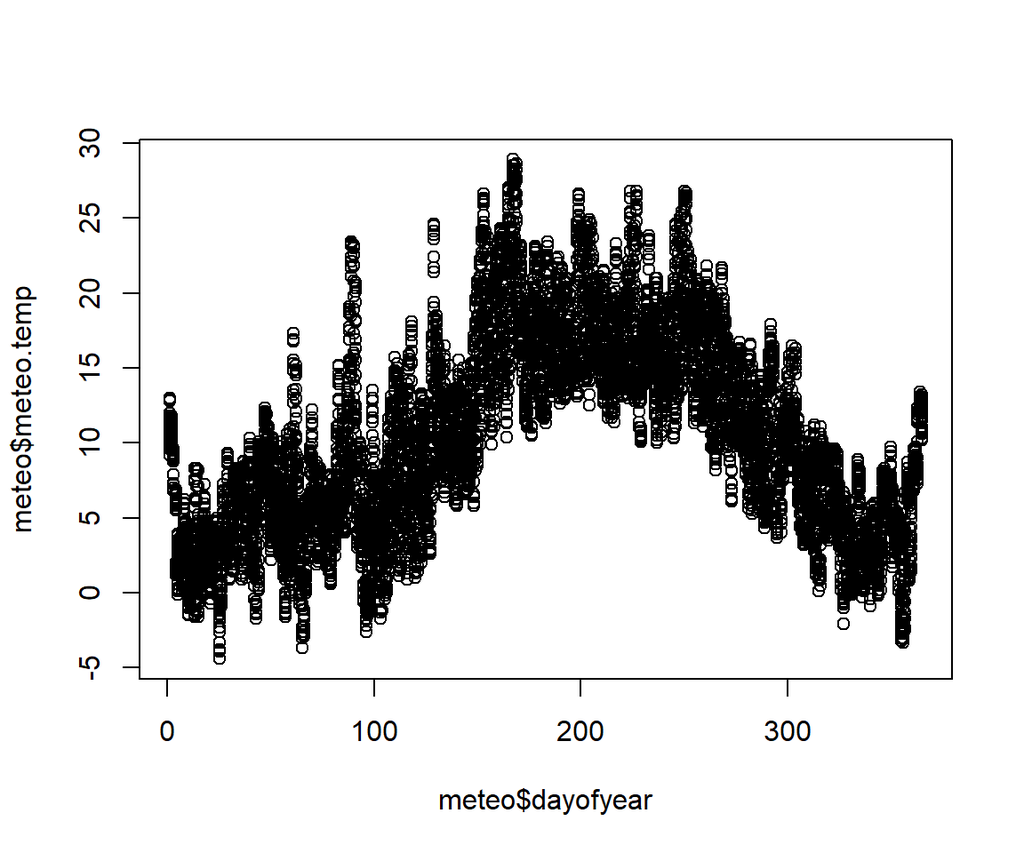

```r
temp <- data.frame(meteo[,'timestamp'],meteo[,'temp'])

#convertire en timestamp
meteo$timestamp <- ymd_hms(meteo$timestamp)
meteo <- data.frame(meteo$timestamp,meteo$temp)
meteo <- na.omit(meteo)

#ici je convertis les dates en jour de l'année (de 1 à 365)
meteo['dayofyear'] <- as.numeric(as.Date(meteo$meteo.timestamp)-as.Date("2021-01-01"))+1

#ici je transforme les jours de l'année plus grand que 365
for (i in c(1:nrow(meteo))){
if(meteo$dayofyear[i]>365) {

  meteo$dayofyear[i] <- (meteo$dayofyear[i] - 365)}
}

#visualisation
plot(meteo$dayofyear,meteo$meteo.temp)
```

```r
head(meteo)
```

```
      meteo.timestamp meteo.temp dayofyear
1 2021-02-27 07:00:00        1.1        58
2 2021-02-27 08:00:00        1.2        58
3 2021-02-27 09:00:00        1.6        58
4 2021-02-27 10:00:00        2.4        58
5 2021-02-27 11:00:00        3.2        58
6 2021-02-27 12:00:00        3.7        58
```

# 3 visualisation des données météo nettoyées

les données proviennent de la région de Charleroi. Charleroi se trouve non loin des grandes régions betteravières Belges. On effectue la moyenne des températures pour chaque jour.

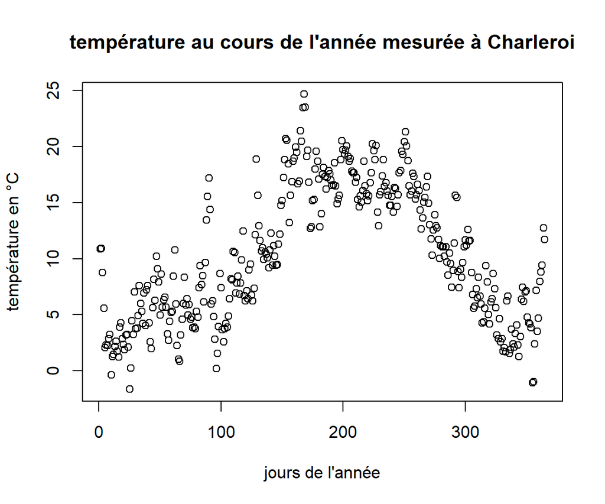

```r
#nécéssaire si plyr a été chargé avant dplyr
#detach(package:plyr)
library(dplyr)

# #je fais la moyenne des températures pour chaque jour
meteo_daily <-  meteo %>% group_by(dayofyear) %>%
                    summarise(temp_daily = mean(meteo.temp))
plot(meteo_daily$dayofyear,meteo_daily$temp_daily,xlab= "jours de l'année",ylab="température en °C", main = "température au cours de l'année mesurée à Charleroi")
```

# 4 modélisation de la température du sol à l’aide d’une sinusoidale

à partir de ces points de données on tente de modéliser l’évolution de la T° par une sinusoidale. Dans la sinusoidale on utilise des paramètres estimés initiaux : la moyenne beta1, l’amplitude beta2 et le déphasage beta3. Ces estimations sont décrites plus loin.

```r
#la moyenne
cat("\n je calcule les paramètres de l'équation qui servira à modéliser la sinusoidale\n ")
```

```
 je calcule les paramètres de l'équation qui servira à modéliser la sinusoidale
```

```r
Beta1 <- mean(meteo_daily$temp_daily)
cat("\n la moyenne : ",Beta1)
```

```
 la moyenne :  10.26252
```

```r
  #'l'amplitude
  Beta2 <- (max(meteo_daily$temp_daily)-min(meteo_daily$temp_daily))/2
  cat("\n l'amplitude : ", Beta2)
```

```
 l'amplitude :  13.14792
```

```r
  daymaxtemp <- meteo_daily$dayofyear[meteo_daily$temp_daily == max(meteo_daily$temp_daily)]

  # le déphasage
    Beta3 <- (pi / 2) - (2 * pi * (daymaxtemp / 365))
  cat('\n le déphasage : ',Beta3)
```

```
 le déphasage :  -1.32119
```

Les paramètres beta1 beta2 et beta3 correspondent à la moyenne des Températures sur l’année, l’amplitude des T° et le déphasage, respectivement. ils ont été estimés comme étant égaux à 1) la moyenne des températures 2) la différence entre la température max et la température min divisée par 2 et 3) la différence entre le moment où le maximum d’une fonction sin normale de produit(pi/2) et le moment où les températures max ont été observées.

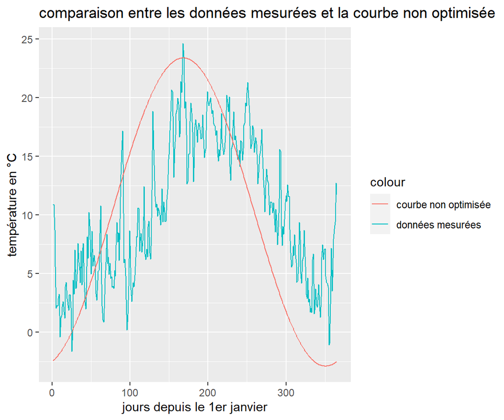

```r
  estimate <- Beta1 + Beta2 * sin(2 * pi * c(1:365) / 365 + Beta3)
  toplot <- data.frame(meteo_daily$temp_daily,estimate)

 ggplot(as.data.frame(toplot), aes(x = c(1:365))) +
  geom_line(aes(y = unlist(toplot[1]), colour = "données mesurées")) +
  geom_line(aes(y = unlist(toplot[2]), colour = "courbe non optimisée")) +
   xlab("jours depuis le 1er janvier") +
           ylab("température en °C") +
   ggtitle("comparaison entre les données mesurées et la courbe non optimisée")
```

## 4.1 optimisation des paramètres

on optimise les paramètres trouvés (beta1..3) pour faire en sorte que la sinusoidale se rapproche le plus des données mesurées. pour ça, on minmise la somme des carrés des erreurs entre les observations et la sinusoidale en jouant sur les betas (méthode de Newton)

```r
 cat("\n la somme des carrés des erreurs de cette première estimation : \n ")
```

```
 la somme des carrés des erreurs de cette première estimation :
```

```r
 #somme des carrésdes erreurs
 SCE<- sum((toplot[1]-toplot[2])**2)
 cat(SCE)
```

```
16747.25
```

```r
 # je fais la sinusoidale sous forme de fonction
 beta <- c(Beta1,Beta2,Beta3)
 x <- c(1:365)

 f<- function(x,beta){beta[1] + beta[2] * sin(2 * pi * x / 365 + beta[3])
 }
 SCE <- function(beta){sum((toplot[1]-f(c(1:365),beta))**2)}

 # on optimise la fonction selon la méthode de newton - raphson
 opti<- optim(beta,SCE,"BFGS")
 cat('\n paramètres optimisés : \n')
```

```
 paramètres optimisés :
```

```r
 cat(opti$par)
```

```
10.26242 7.237983 -1.97274
```

```r
  cat("\n la somme des carrés des erreurs de la courbe optimisée : \n ")
```

```
 la somme des carrés des erreurs de la courbe optimisée :
```

```r
 beta_opti <- c(10.26,7.238,-1.973)
  SCE<- SCE(beta_opti)
 cat(SCE, '\n')
```

```
3256.89
```

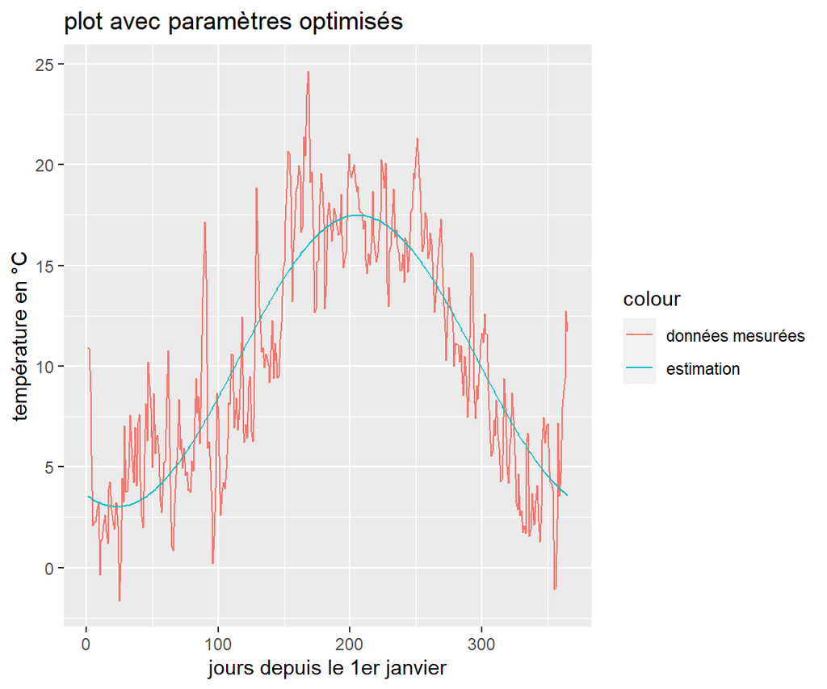

```r
ggplot(as.data.frame(toplot), aes(x = c(1:365))) +
  geom_line(aes(y = unlist(toplot[1]), colour = "données mesurées")) +
  geom_line(aes(y = unlist(f(c(1:365),beta_opti)), colour = "estimation")) +
   xlab("jours depuis le 1er janvier") +
           ylab("température en °C") +
   ggtitle("plot avec paramètres optimisés")
```

## 4.2 modéliser la température à différentes profondeurs

### 4.2.1 hypothèses:

on fait l’approximation que la température juste à la surface du sol = la température mesurée à 1m du sol, ce qui est raisonnable étant donné que les courants de convexion homogénisent la température de l’air

la moyenne des températures (beta1) ne change pas dans notre modèle, parce qu’on admet qu’aux profondeurs qui nous intéressent la chaleur émise par la terre elle-même n’influence pas significativement la température moyenne.

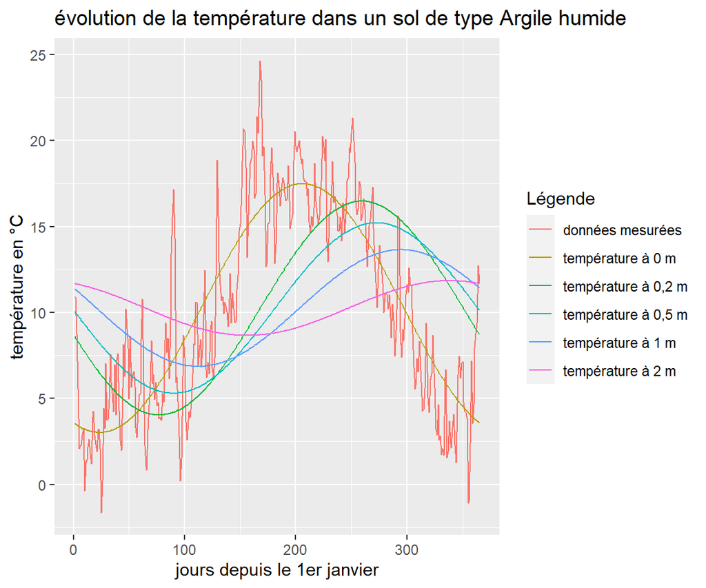

```r
bonk <- as.numeric(f(c(1:365),beta_opti))
lambda <- 0.015 #diffusivité thermique

alpha <-lambda
#/(X*Cp)

soiltemp <- function(depth,alpha) {beta_opti[1] +beta_opti[2]*(exp(-depth*sqrt(pi/(alpha*365))))*cos((((2*pi*c(1:365))/365))-depth*sqrt(pi/((alpha)*365))-beta_opti[3])}

temp20cm <- soiltemp(0.2,0.015)
ggplot(as.data.frame(toplot), aes(x = c(1:365))) +
  geom_line(aes(y = unlist(toplot[1]), colour = "données mesurées")) +
  geom_line(aes(y = unlist(f(c(1:365),beta_opti)), colour = "température à 0 m"))+
  geom_line(aes(y = unlist(soiltemp(0.2,0.015)), colour = "température à 0,2 m")) + xlab("jours depuis le 1er janvier") + geom_line(aes(y = unlist(soiltemp(0.5,0.015)), colour = "température à 0,5 m")) + xlab("jours depuis le 1er janvier") + geom_line(aes(y = unlist(soiltemp(1,0.015)), colour = "température à 1 m")) + xlab("jours depuis le 1er janvier") + geom_line(aes(y = unlist(soiltemp(2,0.015)), colour = "température à 2 m")) + xlab("jours depuis le 1er janvier") +
           ylab("température en °C") +
   ggtitle("évolution de la température dans un sol de type Argile humide") +
  labs(color = "Légende")
```

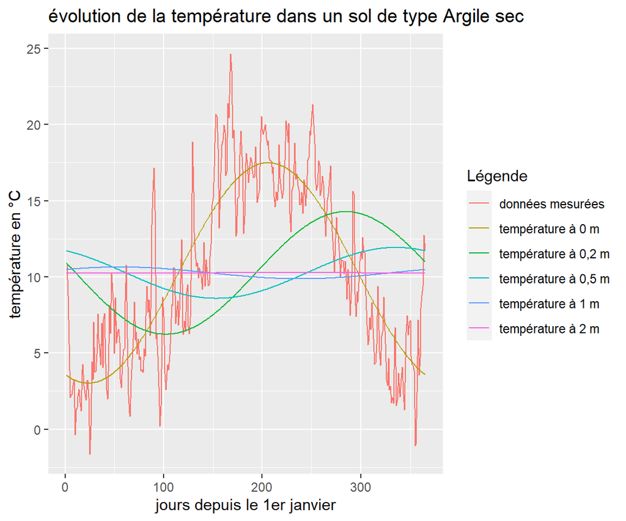

```r
bonk <- as.numeric(f(c(1:365),beta_opti))
lambda <- 0.001 #diffusivité thermique
alpha <-lambda


soiltemp <- function(depth) {beta_opti[1] +beta_opti[2]*(exp(-depth*sqrt(pi/(alpha*365))))*cos((((2*pi*c(1:365))/365))-depth*sqrt(pi/((alpha)*365))-beta_opti[3])}

temp20cm <- soiltemp(0.2)
ggplot(as.data.frame(toplot), aes(x = c(1:365))) +
  geom_line(aes(y = unlist(toplot[1]), colour = "données mesurées")) +
  geom_line(aes(y = unlist(f(c(1:365),beta_opti)), colour = "température à 0 m"))+
  geom_line(aes(y = unlist(soiltemp(0.2)), colour = "température à 0,2 m")) + xlab("jours depuis le 1er janvier") + geom_line(aes(y = unlist(soiltemp(0.5)), colour = "température à 0,5 m")) + xlab("jours depuis le 1er janvier") + geom_line(aes(y = unlist(soiltemp(1)), colour = "température à 1 m")) + xlab("jours depuis le 1er janvier") + geom_line(aes(y = unlist(soiltemp(2)), colour = "température à 2 m")) + xlab("jours depuis le 1er janvier") +
           ylab("température en °C") +
   ggtitle("évolution de la température dans un sol de type Argile sec") +
  labs(color = "Légende")
```

# 5 calculer les paramètres racinaires

Cette dernière section a servi à extraire certains paramètres racinaires de smartroot. elle n’est donc pas liée directement à la modélisation de la température dans le sol.

```r
by_root <- root_growth %>% group_by(root_name) %>%
                    summarise(total_length = sum(growth),
                              initial_elongation_rate =sum(growth)/(date[length(date)]-date[1]+1), root_order =root_order[1])
by_root <- by_root[!(by_root$initial_elongation_rate<0),]
average_growth_rates <- by_root %>% group_by(root_order) %>% summarise(average_initial_growth_rate = mean(initial_elongation_rate))

write.csv(average_growth_rates,"C:/Users/artur/OneDrive/Documents/cours/modélisation/average_growth_rates.csv")

average_insertion_angle <- global_data %>% group_by(root_order) %>%
                    summarise(mean(insertion_angle))

cat("\n average growth rates \n")
```

```
 average growth rates
```

```r
pander(average_growth_rates)
```

```
------------------------------------------
 root_order   average_initial_growth_rate
------------ -----------------------------
     0                   1.762

     1                  0.3802
------------------------------------------
```

```r
cat("\n average insertion angles \n")
```

```
 average insertion angles
```

```r
pander(average_insertion_angle)
```

```
------------------------------------
 root_order   mean(insertion_angle)
------------ -----------------------
     0                -57.3

     1                74.51
------------------------------------
```

```r
cat("\n other params \n")
```

```
 other params
```

```r
pander(global_data)
```

[output not shown]

[output cut: 367 more lines]

[output not shown]